# ING

```python
import pandas as pd
import numpy as np
import datetime
import matplotlib.pyplot as plt
from linearmodels.panel import RandomEffects
from linearmodels.panel import PanelOLS
import statsmodels.api as sm
from linearmodels.panel import compare
```

To value residential fixed-rate mortgages, an accurate prediction of future prepayment rates is crucial. The attached data sets (mortgage_data.xlsx and refinancing_rate_data.xlsx) contain prepayment data.

The Excel file “mortgage_data.xlsx” contains the following variables: • Client_ID: Unique identifier. Each client gets his own ID.

• Date: the date at which we observe the prepayment rate and the other rates.

• PP_rate (%): the prepayment rate in percentages.

• Starting_notional: the contract’s initial notional (the amount the client borrowed initially).

• Client_rate (%): the rate in percentages the client must pay.

• Loan_start_date: the start date of the mortgage contract.

• Loan_end_date: the maturity date of the mortgage contract.

• Remaining_maturity (M): the remaining maturity of the contract in months.

• Outstanding_notional: the outstanding notional at the date.

• The values are end of the month.

• The time window ranges from January 2016 to December 2018.

The Excel file “refinancing_rate_data.xlsx” contains the following variables:

• Date: the date at which we observe the prepayment rate and the other rates.

• Refinancing rate (%): the rate in percentages for which the bank can sell a new comparable mortgage with similar characteristics to the ones in the file “mortgage_data.xlsx.”

# Part I. Data analysis

We begin by analyzing the data and identifying potential issues. Notably, observations with zero outstanding notional could distort our findings. Therefore, we remove these entries to ensure data integrity. Next, we merge two Excel files and calculate the difference between the client rate and the refinancing rate. This step is grounded in financial theory: for fixed mortgage rates, a lower refinancing rate incentivizes clients to refinance their existing mortgages.

```python
df = pd.read_excel("mortgage_data.xlsx", sheet_name = "Mortgage data")
rr_ = pd.read_excel("refinancing_rate_data.xlsx")

df['Date'] = pd.to_datetime(df['Date'])
rr_['Date'] = pd.to_datetime(rr_['Date'])

rr_.set_index('Date', inplace=True)
df = df.merge(rr_, on='Date').sort_values(by=['Client_ID', 'Date'])
df.rename(columns={'PP_rate (%)': 'PP_rate', 'Client_rate (%)': 'Client_rate'}, inplace=True)   #rename for convenience

df = df[df['Outstanding_notional'] != 0]                          # Remove rows with zero outstanding notional

df['Loan_start_year'] = df['Loan_start_date'].dt.year
df['Payment month'] = df["Date"].dt.month
df['Rates delta'] = df['Refinancing rate'] - df['Client_rate']    # Calculate the rate difference
df['Share of debt repaid'] = np.where(df["Client_ID"] == df["Client_ID"].shift(-1),(df["Starting_notional"] - df["Outstanding_notional"].shift(-1)) / df["Starting_notional"], np.nan)  # Calculate the share of debt repaid
df["Duration"] = ((df["Loan_end_date"] - df['Loan_start_date']).dt.days)/365        #calculate the length of the mortgage
df.sort_values(by=['Client_ID', 'Date'], inplace=True)
#df.bfill(inplace=True)

df.head()
```

|  | Client_ID | Date | PP_rate | Starting_notional | Client_rate | Loan_start_date | Loan_end_date | Remaining_maturity (M) | Outstanding_notional | Refinancing rate | Loan_start_year | Payment month | Rates delta | Share of debt repaid | Duration |
| --- | --- | --- | --- | --- | --- | --- | --- | --- | --- | --- | --- | --- | --- | --- | --- |
| 0 | 0 | 2016-01-31 | 0.005125 | 571372.828731 | 0.041953 | 2011-08-24 12:46:36 | 2025-08-23 12:46:36 | 114 | 571372.828731 | 0.02768 | 2011 | 1 | -0.014273 | 0.012252 | 14.008219 |
| 25 | 0 | 2016-02-29 | 0.006316 | 571372.828731 | 0.041953 | 2011-08-24 12:46:36 | 2025-08-23 12:46:36 | 113 | 564372.241635 | 0.02730 | 2011 | 2 | -0.014653 | 0.021651 | 14.008219 |
| 50 | 0 | 2016-03-31 | 0.005955 | 571372.828731 | 0.041953 | 2011-08-24 12:46:36 | 2025-08-23 12:46:36 | 112 | 559002.242496 | 0.02665 | 2011 | 3 | -0.015303 | 0.031806 | 14.008219 |
| 75 | 0 | 2016-04-30 | 0.005724 | 571372.828731 | 0.041953 | 2011-08-24 12:46:36 | 2025-08-23 12:46:36 | 111 | 553199.871964 | 0.02657 | 2011 | 4 | -0.015383 | 0.043403 | 14.008219 |
| 100 | 0 | 2016-05-31 | 0.008250 | 571372.828731 | 0.041953 | 2011-08-24 12:46:36 | 2025-08-23 12:46:36 | 110 | 546573.739386 | 0.02651 | 2011 | 5 | -0.015443 | 0.056874 | 14.008219 |

At this stage we should make some hypotheses. We should expect some seasonality - e.g., clients may be more active in debt repayment after getting bonuses/13th salary

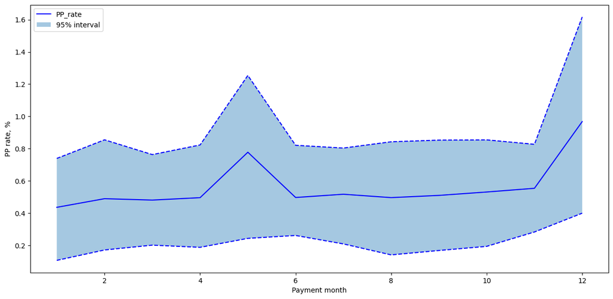

```python
upper = df.groupby('Payment month')['PP_rate'].quantile(0.975)*100
lower = df.groupby('Payment month')['PP_rate'].quantile(0.025)*100

plt.figure(figsize=(15, 7))
(df.groupby(['Payment month'])['PP_rate'].mean() * 100).plot(color=['blue', 'magenta'])
upper.plot(color='blue', linestyle='--',label='_nolegend_')
lower.plot(color='blue', linestyle='--',label='_nolegend_')
plt.fill_between(df.groupby('Payment month')['PP_rate'].mean().index, lower, upper, alpha=0.4, label="95% interval")
plt.ylabel("PP rate, %")
plt.legend()
plt.show();
```

Plot above indeed shows presence of seasonality. Further analysis showed that highest PP rates were obtained in Dec and May.

Also, as indicated above, it is natural to expect higher repayment rate when refinancing rates are getting lower

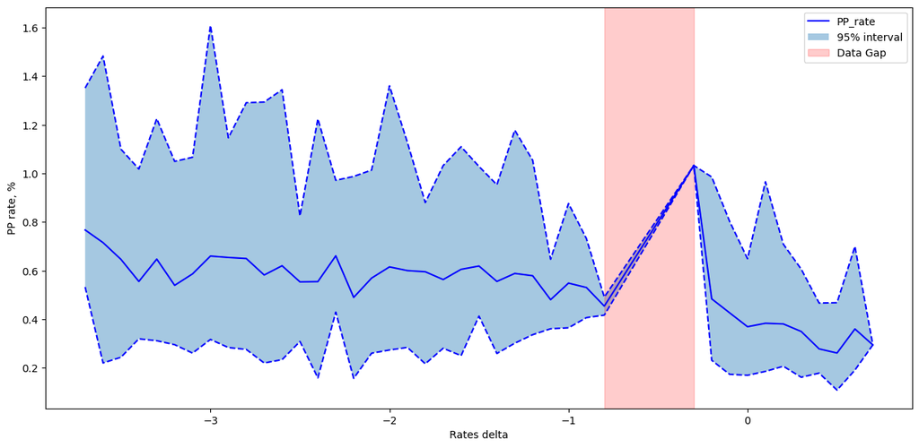

```python
upper = df.groupby(round((df['Rates delta']*100), 1))['PP_rate'].quantile(0.975)*100
lower = df.groupby(round((df['Rates delta']*100), 1))['PP_rate'].quantile(0.025)*100
r = df.groupby([round((df['Rates delta']*100), 1)])['PP_rate'].mean()*100

plt.figure(figsize=(15, 7))
r.plot(color=['blue', 'magenta'])
upper.plot(color='blue', linestyle='--',label='_nolegend_')
lower.plot(color='blue', linestyle='--',label='_nolegend_')
plt.fill_between(df.groupby(round((df['Rates delta']*100), 1))['PP_rate'].mean().index, lower, upper, alpha=0.4, label="95% interval")
plt.axvspan(-0.8, -0.3, color='red', alpha=0.2, label="Data Gap")
plt.ylabel("PP rate, %")
plt.legend()
plt.show()
```

We indeed can see an inverse relation between delta rate and PP rate, though it is not so particularly pronounced as expected. Still, further data analysis indicates that extreme values are more likely to be obtained when rates decrease. Note that we see a structural break due to pecularities of data

Also, we might expect that maturity has certain effect. For example, lower maturity may have psychologically incentivize people to pay back the debt (leave it in the past asap), or coincide with the higher income level

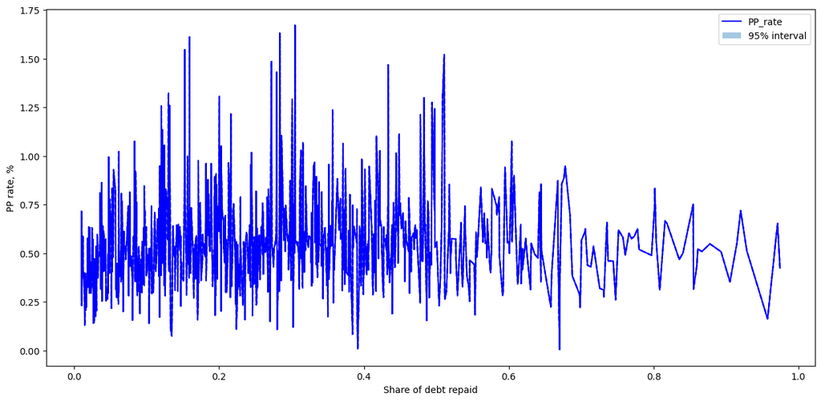

```python
plt.figure(figsize=(15, 7))
upper = (df.groupby('Share of debt repaid')['PP_rate'].quantile(0.975)) * 100
lower = (df.groupby('Share of debt repaid')['PP_rate'].quantile(0.025)) * 100
(df.groupby(['Share of debt repaid'])['PP_rate'].mean() * 100).plot(color=['blue', 'magenta'])
upper.plot(color='blue', linestyle='--',label='_nolegend_')
lower.plot(color='blue', linestyle='--',label='_nolegend_')
plt.fill_between(df.groupby('Share of debt repaid')['PP_rate'].mean().index, lower, upper, alpha=0.4, label="95% interval")
plt.ylabel("PP rate, %")
plt.legend()
plt.show()
```

We also can assume that there is a correlation between the starting notional and the PP rate - wealthier people tend to pay back faster

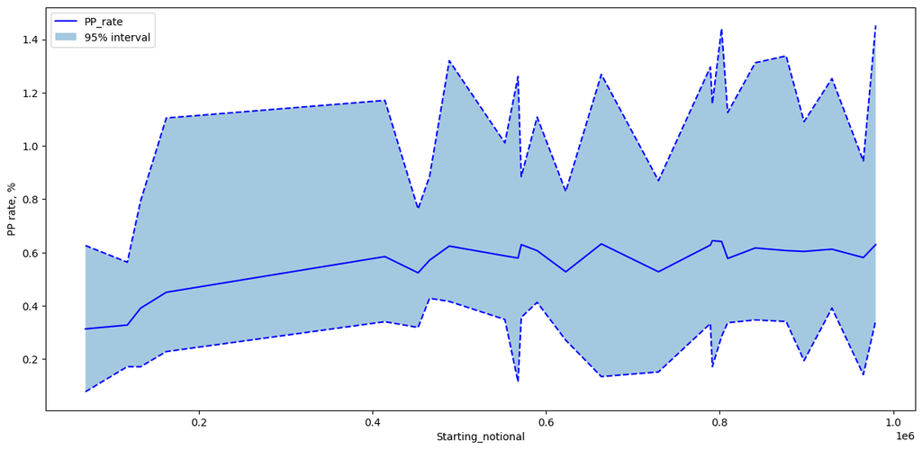

```python
plt.figure(figsize=(15, 7))
upper = (df.groupby('Starting_notional')['PP_rate'].quantile(0.975)) * 100
lower = (df.groupby('Starting_notional')['PP_rate'].quantile(0.025)) * 100
(df.groupby(['Starting_notional'])['PP_rate'].mean() * 100).plot(color=['blue', 'magenta'])
upper.plot(color='blue', linestyle='--',label='_nolegend_')
lower.plot(color='blue', linestyle='--',label='_nolegend_')
plt.fill_between(df.groupby('Starting_notional')['PP_rate'].mean().index, lower, upper, alpha=0.4, label="95% interval")
plt.ylabel("PP rate, %")
plt.legend()
plt.show()
```

# Part II. Linear models

The most obvious candidate to start with is the panel data regression. We will try both fixed and random effect and compare models

We also add binary variable to detect seasonality and to account for the size of starting notional

```python
df_model = df.copy()
df_model["Dec"] = (df_model['Payment month'] == 12)*1
df_model["May"] = (df_model['Payment month'] == 5)*1
df_model["above average"] = (df_model["Starting_notional"] > 400000)*1                        #average mortgage in the Netherlands

Date = pd.Categorical(df_model.Date)
df_model.set_index(["Client_ID", "Date"], inplace = True)

df_model = df_model[['PP_rate','Rates delta', 'Dec', 'May', 'above average']]  #leave the necessary columns
df_model
```

| Client_ID | Date | PP_rate | Rates delta | Dec | May | above average |
| --- | --- | --- | --- | --- | --- | --- |
| 0 | 2016-01-31 | 0.005125 | -0.014273 | 0 | 0 | 1 |
|  | 2016-02-29 | 0.006316 | -0.014653 | 0 | 0 | 1 |
|  | 2016-03-31 | 0.005955 | -0.015303 | 0 | 0 | 1 |
|  | 2016-04-30 | 0.005724 | -0.015383 | 0 | 0 | 1 |
|  | 2016-05-31 | 0.008250 | -0.015443 | 0 | 1 | 1 |
| ... | ... | ... | ... | ... | ... | ... |
| 24 | 2018-08-31 | 0.003835 | -0.002141 | 0 | 0 | 0 |
|  | 2018-09-30 | 0.005357 | -0.002241 | 0 | 0 | 0 |
|  | 2018-10-31 | 0.002604 | -0.002341 | 0 | 0 | 0 |
|  | 2018-11-30 | 0.006253 | -0.002441 | 0 | 0 | 0 |
|  | 2018-12-31 | 0.010327 | -0.002541 | 1 | 0 | 0 |

866 rows × 5 columns

```python
exog = sm.add_constant(df_model.drop(columns = ['PP_rate']))
mod_RE = RandomEffects(df_model.PP_rate, exog)
res_RE = mod_RE.fit()
print(res_RE)
```

```
                        RandomEffects Estimation Summary
================================================================================
Dep. Variable:                PP_rate   R-squared:                        0.4419
Estimator:              RandomEffects   R-squared (Between):              0.8115
No. Observations:                 866   R-squared (Within):               0.4123
Date:                Mon, Dec 16 2024   R-squared (Overall):              0.4671
Time:                        21:27:18   Log-likelihood                    4269.6
Cov. Estimator:            Unadjusted
                                        F-statistic:                      170.43
Entities:                          25   P-value                           0.0000
Avg Obs:                       34.640   Distribution:                   F(4,861)
Min Obs:                       22.000
Max Obs:                       36.000   F-statistic (robust):             170.76
                                        P-value                           0.0000
Time periods:                      36   Distribution:                   F(4,861)
Avg Obs:                       24.056
Min Obs:                       21.000
Max Obs:                       25.000

                               Parameter Estimates
=================================================================================
               Parameter  Std. Err.     T-stat    P-value    Lower CI    Upper CI
---------------------------------------------------------------------------------
const             0.0032     0.0002     14.822     0.0000      0.0027      0.0036
Rates delta      -0.0395     0.0117    -3.3713     0.0008     -0.0626     -0.0165
Dec               0.0046     0.0002     21.130     0.0000      0.0042      0.0051
May               0.0028     0.0002     12.974     0.0000      0.0024      0.0032
above average     0.0013     0.0004     3.4749     0.0005      0.0006      0.0020
=================================================================================
```

```python
mod_FE = PanelOLS(df_model.PP_rate, exog)
res_FE = mod_FE.fit()
print(res_FE)
```

```
                          PanelOLS Estimation Summary
================================================================================
Dep. Variable:                PP_rate   R-squared:                        0.4680
Estimator:                   PanelOLS   R-squared (Between):              0.8284
No. Observations:                 866   R-squared (Within):               0.4104
Date:                Mon, Dec 16 2024   R-squared (Overall):              0.4680
Time:                        21:27:18   Log-likelihood                    4259.0
Cov. Estimator:            Unadjusted
                                        F-statistic:                      189.32
Entities:                          25   P-value                           0.0000
Avg Obs:                       34.640   Distribution:                   F(4,861)
Min Obs:                       22.000
Max Obs:                       36.000   F-statistic (robust):             189.32
                                        P-value                           0.0000
Time periods:                      36   Distribution:                   F(4,861)
Avg Obs:                       24.056
Min Obs:                       21.000
Max Obs:                       25.000

                               Parameter Estimates
=================================================================================
               Parameter  Std. Err.     T-stat    P-value    Lower CI    Upper CI
---------------------------------------------------------------------------------
const             0.0032     0.0002     20.460     0.0000      0.0029      0.0035
Rates delta      -0.0298     0.0086    -3.4756     0.0005     -0.0466     -0.0130
Dec               0.0046     0.0002     20.917     0.0000      0.0042      0.0051
May               0.0028     0.0002     12.812     0.0000      0.0024      0.0032
above average     0.0015     0.0003     5.6466     0.0000      0.0010      0.0020
=================================================================================
```

```python
print(compare({"FE": res_FE, "RE": res_RE}))
```

```
                 Model Comparison
==================================================
                                FE              RE
--------------------------------------------------
Dep. Variable              PP_rate         PP_rate
Estimator                 PanelOLS   RandomEffects
No. Observations               866             866
Cov. Est.               Unadjusted      Unadjusted
R-squared                   0.4680          0.4419
R-Squared (Within)          0.4104          0.4123
R-Squared (Between)         0.8284          0.8115
R-Squared (Overall)         0.4680          0.4671
F-statistic                 189.32          170.43
P-value (F-stat)            0.0000          0.0000
===================== ============ ===============
const                       0.0032          0.0032
                          (20.460)        (14.822)
Rates delta                -0.0298         -0.0395
                         (-3.4756)       (-3.3713)
Dec                         0.0046          0.0046
                          (20.917)        (21.130)
May                         0.0028          0.0028
                          (12.812)        (12.974)
above average               0.0015          0.0013
                          (5.6466)        (3.4749)
--------------------------------------------------

T-stats reported in parentheses
```

# Part III. Sensitivity analysis

Now we use our model to check the sensitivity of depend variable in changes in regressors

```python
predictions_rate = pd.Series()
predictions_seasonality = pd.Series()
predictions_avg = pd.Series()

client_rate = df['Client_rate'].mean()
rr_rate = df['Refinancing rate'].mean()
dec = 0
may = 0
above_average = 1  # as most of mortgagges are above the Dutch average, we leave 1

def sensitivity(client_rate, rr_rate, dec, may, above_avg):
    test = pd.DataFrame({
        'Const': [1],
        'Rates delta': [rr_rate - client_rate],
        'Dec': [dec],
        'May': [may],
        'above average': [above_avg]}, index = [0])
    test['Date'] = pd.to_datetime('2020-12-31')
    test['Client_ID'] = 30
    test = test.set_index(['Client_ID', 'Date'])
    sens = res_FE.predict(test).values.mean()*100
    return sens

for rr in (np.linspace(1,3,6)):
    predictions_rate[rr] = sensitivity(client_rate, rr/100, dec, may, above_average)

for i, month in enumerate(zip([0,0,1], [0,1,0])):
    predictions_seasonality[i] = sensitivity(client_rate, rr_rate, month[0], month[1], above_average)
predictions_seasonality.index = ['Other months', 'May', 'Dec']

for avg in [0,1]:
    predictions_avg[avg] = sensitivity(client_rate, rr_rate, dec, may, avg)
predictions_avg.index = ['Below average', 'Above average']
```

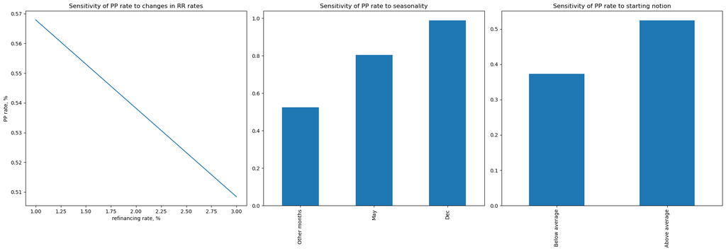

```python
fig, axes = plt.subplots(nrows=1, ncols=3, figsize=(20, 7))
predictions_rate.plot(ax=axes[0], title='Sensitivity of PP rate to changes in RR rates')
predictions_seasonality.plot.bar(ax=axes[1], title='Sensitivity of PP rate to seasonality')
predictions_avg.plot.bar(ax=axes[2], title='Sensitivity of PP rate to starting notion')


axes[0].set_ylabel('PP rate, %')
axes[0].set_xlabel('refinancing rate, %')

plt.tight_layout()
plt.show()
```

# Part IV. Valuation

Simulate the interest rate path by means of the Vasicek model:

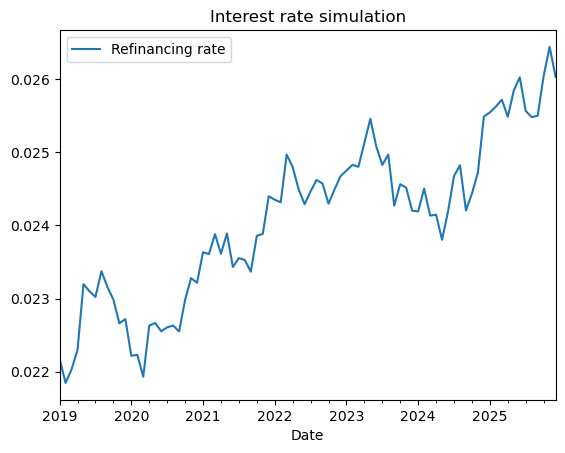

```python
def vasicek_simulation(r0, kappa, theta, sigma, T, steps):
    """
    The Vasicek Model to simulate the interest rate path
    """
    dt = T / steps
    rates = [r0]
    for _ in range(steps):
        dr = kappa * (theta - rates[-1]) * dt + sigma * np.sqrt(dt) * np.random.normal()
        rates.append(rates[-1] + dr)
    return rates[1:]

theta = rr_.mean()     #long-term average
r0 = rr_.iloc[-1]
kappa=0.1              # mean reversion

date_range = pd.date_range(start='2019-01-01', end='2025-12-31', freq='M')

rate_paths = np.array([vasicek_simulation(r0, kappa, theta, sigma=0.01, T = len(date_range)/12, steps=len(date_range)) for _ in range(100)]) # Simulate 10 years of refinancing rates
rate_path = np.mean(rate_paths, axis=0)
rr = pd.DataFrame(rate_path, index=date_range, columns = ['Refinancing rate'])
rr.index.name = "Date"
rr.plot(title='Interest rate simulation');
```

We drop clients who paid off their debt - these are clients #10,11,16,21

```python
val_df = df[~df["Client_ID"].isin([10, 11,16,21])]

rrr = rr.reset_index()

for i in val_df["Client_ID"].unique():
    val_df = pd.concat([val_df, rrr])
    val_df.fillna({'Starting_notional': val_df.loc[val_df["Client_ID"] == i, 'Starting_notional'].iloc[0],
                     'Client_rate': val_df.loc[val_df["Client_ID"] == i, 'Client_rate'].iloc[0],
                     'Client_ID': i, "Duration": val_df.loc[val_df["Client_ID"] == i, "Duration"].iloc[0]}, inplace=True)

val_df.drop(columns = ['Loan_start_date', 'Loan_end_date', 'Remaining_maturity (M)', 'Loan_start_year', 'Payment month', 'Share of debt repaid'], inplace = True)
val_df
```

|  | Client_ID | Date | PP_rate | Starting_notional | Client_rate | Outstanding_notional | Refinancing rate | Rates delta | Duration |
| --- | --- | --- | --- | --- | --- | --- | --- | --- | --- |
| 0 | 0.0 | 2016-01-31 | 0.005125 | 571372.828731 | 0.041953 | 571372.828731 | 0.027680 | -0.014273 | 14.008219 |
| 25 | 0.0 | 2016-02-29 | 0.006316 | 571372.828731 | 0.041953 | 564372.241635 | 0.027300 | -0.014653 | 14.008219 |
| 50 | 0.0 | 2016-03-31 | 0.005955 | 571372.828731 | 0.041953 | 559002.242496 | 0.026650 | -0.015303 | 14.008219 |
| 75 | 0.0 | 2016-04-30 | 0.005724 | 571372.828731 | 0.041953 | 553199.871964 | 0.026570 | -0.015383 | 14.008219 |
| 100 | 0.0 | 2016-05-31 | 0.008250 | 571372.828731 | 0.041953 | 546573.739386 | 0.026510 | -0.015443 | 14.008219 |
| ... | ... | ... | ... | ... | ... | ... | ... | ... | ... |
| 79 | 24.0 | 2025-08-31 | NaN | 162360.704575 | 0.024731 | NaN | 0.025480 | NaN | 14.430137 |
| 80 | 24.0 | 2025-09-30 | NaN | 162360.704575 | 0.024731 | NaN | 0.025498 | NaN | 14.430137 |
| 81 | 24.0 | 2025-10-31 | NaN | 162360.704575 | 0.024731 | NaN | 0.026042 | NaN | 14.430137 |
| 82 | 24.0 | 2025-11-30 | NaN | 162360.704575 | 0.024731 | NaN | 0.026439 | NaN | 14.430137 |
| 83 | 24.0 | 2025-12-31 | NaN | 162360.704575 | 0.024731 | NaN | 0.026029 | NaN | 14.430137 |

2520 rows × 9 columns

Add the columnns with the refinancing rate forecast:

Given our rate prediction, we forecast the PP rate. We assume that from now on the implied (contractual) payment is calculated by the formula of a Fixed-Rate Loan Payment:

$$ P = \frac{r \cdot PV}{1 - (1 + r)^{-n}} $$

Sum of all the discounted future payments (those under terms plus prepayment) is the theoretical value of the mortgage

```python
val_df["Dec"] = (val_df["Date"].dt.month == 12)*1
val_df["May"] = (val_df["Date"].dt.month == 5)*1
val_df["Rates delta"] = val_df['Refinancing rate'] - val_df['Client_rate']
val_df["Amortization"] = ((val_df['Client_rate'] * val_df['Starting_notional']) / (1 - (1+val_df['Client_rate'])**-val_df["Duration"]))/12
val_df.loc[val_df["Date"] == "2019-01-31", "Outstanding_notional"] = (val_df.loc[val_df["Date"] == "2018-12-31", "Outstanding_notional"] \
                            - val_df.loc[val_df["Date"] == "2018-12-31", "Amortization"] \
                            - val_df.loc[val_df["Date"] == "2018-12-31", "PP_rate"] * val_df.loc[val_df["Date"] == "2018-12-31", "Outstanding_notional"]).values
val_df["const"] = 1  #for modelling
val_df["above average"] = (val_df["Starting_notional"] > 400000)*1

val_df
```

|  | Client_ID | Date | PP_rate | Starting_notional | Client_rate | Outstanding_notional | Refinancing rate | Rates delta | Duration | Dec | May | Amortization | const | above average |
| --- | --- | --- | --- | --- | --- | --- | --- | --- | --- | --- | --- | --- | --- | --- |
| 0 | 0.0 | 2016-01-31 | 0.005125 | 571372.828731 | 0.041953 | 571372.828731 | 0.027680 | -0.014273 | 14.008219 | 0 | 0 | 4563.921417 | 1 | 1 |
| 25 | 0.0 | 2016-02-29 | 0.006316 | 571372.828731 | 0.041953 | 564372.241635 | 0.027300 | -0.014653 | 14.008219 | 0 | 0 | 4563.921417 | 1 | 1 |
| 50 | 0.0 | 2016-03-31 | 0.005955 | 571372.828731 | 0.041953 | 559002.242496 | 0.026650 | -0.015303 | 14.008219 | 0 | 0 | 4563.921417 | 1 | 1 |
| 75 | 0.0 | 2016-04-30 | 0.005724 | 571372.828731 | 0.041953 | 553199.871964 | 0.026570 | -0.015383 | 14.008219 | 0 | 0 | 4563.921417 | 1 | 1 |
| 100 | 0.0 | 2016-05-31 | 0.008250 | 571372.828731 | 0.041953 | 546573.739386 | 0.026510 | -0.015443 | 14.008219 | 0 | 1 | 4563.921417 | 1 | 1 |
| ... | ... | ... | ... | ... | ... | ... | ... | ... | ... | ... | ... | ... | ... | ... |
| 79 | 24.0 | 2025-08-31 | NaN | 162360.704575 | 0.024731 | NaN | 0.025480 | 0.000749 | 14.430137 | 0 | 0 | 1126.287625 | 1 | 0 |
| 80 | 24.0 | 2025-09-30 | NaN | 162360.704575 | 0.024731 | NaN | 0.025498 | 0.000767 | 14.430137 | 0 | 0 | 1126.287625 | 1 | 0 |
| 81 | 24.0 | 2025-10-31 | NaN | 162360.704575 | 0.024731 | NaN | 0.026042 | 0.001311 | 14.430137 | 0 | 0 | 1126.287625 | 1 | 0 |
| 82 | 24.0 | 2025-11-30 | NaN | 162360.704575 | 0.024731 | NaN | 0.026439 | 0.001708 | 14.430137 | 0 | 0 | 1126.287625 | 1 | 0 |
| 83 | 24.0 | 2025-12-31 | NaN | 162360.704575 | 0.024731 | NaN | 0.026029 | 0.001298 | 14.430137 | 1 | 0 | 1126.287625 | 1 | 0 |

2520 rows × 14 columns

Format the data:

```python
n_val_df = val_df[val_df['Date'].dt.year >= 2019]
n_val_df.set_index(["Client_ID", "Date"], inplace = True)
pred_val_df = n_val_df[['const',"Rates delta", "Dec", "May", 'above average']]
pred_val_df
```

| Client_ID | Date | const | Rates delta | Dec | May | above average |
| --- | --- | --- | --- | --- | --- | --- |
| 0.0 | 2019-01-31 | 1 | -0.019774 | 0 | 0 | 1 |
|  | 2019-02-28 | 1 | -0.020106 | 0 | 0 | 1 |
|  | 2019-03-31 | 1 | -0.019922 | 0 | 0 | 1 |
|  | 2019-04-30 | 1 | -0.019652 | 0 | 0 | 1 |
|  | 2019-05-31 | 1 | -0.018756 | 0 | 1 | 1 |
| ... | ... | ... | ... | ... | ... | ... |
| 24.0 | 2025-08-31 | 1 | 0.000749 | 0 | 0 | 0 |
|  | 2025-09-30 | 1 | 0.000767 | 0 | 0 | 0 |
|  | 2025-10-31 | 1 | 0.001311 | 0 | 0 | 0 |
|  | 2025-11-30 | 1 | 0.001708 | 0 | 0 | 0 |
|  | 2025-12-31 | 1 | 0.001298 | 1 | 0 | 0 |

1764 rows × 5 columns

Predict the PP rate:

```python
RR = res_FE.predict(pred_val_df)
RR
```

| Client_ID | Date | predictions |
| --- | --- | --- |
| 0.0 | 2019-01-31 | 0.005264 |
|  | 2019-02-28 | 0.005274 |
|  | 2019-03-31 | 0.005268 |
|  | 2019-04-30 | 0.005260 |
|  | 2019-05-31 | 0.008026 |
| ... | ... | ... |
| 24.0 | 2025-08-31 | 0.003143 |
|  | 2025-09-30 | 0.003142 |
|  | 2025-10-31 | 0.003126 |
|  | 2025-11-30 | 0.003114 |
|  | 2025-12-31 | 0.007776 |

1764 rows × 1 columns

```python
n_val_df.loc[:, "PP_rate"] = RR["predictions"].values
n_val_df = n_val_df[['PP_rate', 'Client_rate', 'Refinancing rate', 'Outstanding_notional', 'Amortization']].reset_index() #leave only necessary columns
n_val_df["Payment"] = np.nan
n_val_df
```

|  | Client_ID | Date | PP_rate | Client_rate | Refinancing rate | Outstanding_notional | Amortization | Payment |
| --- | --- | --- | --- | --- | --- | --- | --- | --- |
| 0 | 0.0 | 2019-01-31 | 0.005264 | 0.041953 | 0.022179 | 285093.75995 | 4563.921417 | NaN |
| 1 | 0.0 | 2019-02-28 | 0.005274 | 0.041953 | 0.021847 | NaN | 4563.921417 | NaN |
| 2 | 0.0 | 2019-03-31 | 0.005268 | 0.041953 | 0.022031 | NaN | 4563.921417 | NaN |
| 3 | 0.0 | 2019-04-30 | 0.005260 | 0.041953 | 0.022300 | NaN | 4563.921417 | NaN |
| 4 | 0.0 | 2019-05-31 | 0.008026 | 0.041953 | 0.023197 | NaN | 4563.921417 | NaN |
| ... | ... | ... | ... | ... | ... | ... | ... | ... |
| 1759 | 24.0 | 2025-08-31 | 0.003143 | 0.024731 | 0.025480 | NaN | 1126.287625 | NaN |
| 1760 | 24.0 | 2025-09-30 | 0.003142 | 0.024731 | 0.025498 | NaN | 1126.287625 | NaN |
| 1761 | 24.0 | 2025-10-31 | 0.003126 | 0.024731 | 0.026042 | NaN | 1126.287625 | NaN |
| 1762 | 24.0 | 2025-11-30 | 0.003114 | 0.024731 | 0.026439 | NaN | 1126.287625 | NaN |
| 1763 | 24.0 | 2025-12-31 | 0.007776 | 0.024731 | 0.026029 | NaN | 1126.287625 | NaN |

1764 rows × 8 columns

```python
for i in range(1,len(n_val_df["Date"].unique())):
    p_date = n_val_df["Date"][i-1]
    c_date = n_val_df["Date"][i]

    balance = (n_val_df.loc[n_val_df["Date"] == p_date, "Outstanding_notional"] \
                            - n_val_df.loc[n_val_df["Date"] == p_date, "Amortization"] \
                            - n_val_df.loc[n_val_df["Date"] == p_date, "PP_rate"] * n_val_df.loc[n_val_df["Date"] == p_date, "Outstanding_notional"]).values

    n_val_df.loc[n_val_df["Date"] == c_date, "Outstanding_notional"] = np.where(balance>0, balance, 0)
    n_val_df.loc[n_val_df["Date"] == p_date, "Payment"] = (n_val_df.loc[n_val_df["Date"] == p_date, "Outstanding_notional"]).values - (n_val_df.loc[n_val_df["Date"] == c_date, "Outstanding_notional"]).values

valuation = n_val_df[['Client_ID', 'Date', 'Refinancing rate', 'Outstanding_notional', "Payment"]]
valuation
```

|  | Client_ID | Date | Refinancing rate | Outstanding_notional | Payment |
| --- | --- | --- | --- | --- | --- |
| 0 | 0.0 | 2019-01-31 | 0.022179 | 285093.759950 | 6064.648876 |
| 1 | 0.0 | 2019-02-28 | 0.021847 | 279029.111074 | 6035.481294 |
| 2 | 0.0 | 2019-03-31 | 0.022031 | 272993.629781 | 6002.154631 |
| 3 | 0.0 | 2019-04-30 | 0.022300 | 266991.475150 | 5968.395383 |
| 4 | 0.0 | 2019-05-31 | 0.023197 | 261023.079767 | 6658.971259 |
| ... | ... | ... | ... | ... | ... |
| 1759 | 24.0 | 2025-08-31 | 0.025480 | 0.000000 | 0.000000 |
| 1760 | 24.0 | 2025-09-30 | 0.025498 | 0.000000 | 0.000000 |
| 1761 | 24.0 | 2025-10-31 | 0.026042 | 0.000000 | 0.000000 |
| 1762 | 24.0 | 2025-11-30 | 0.026439 | 0.000000 | 0.000000 |
| 1763 | 24.0 | 2025-12-31 | 0.026029 | 0.000000 | NaN |

1764 rows × 5 columns

We use the fact that the present value of an asset is:

$$ PV = \sum_{t=1}^{n} \frac{C_t}{(1 + r_t)^t} $$

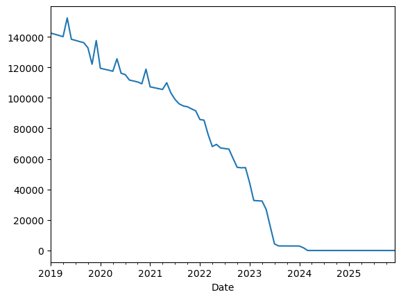

```python
payments = valuation.groupby(["Date"])["Payment"].sum()
payments.plot();
payments = rrr.set_index("Date").join(payments)
payments["PV"] = payments["Payment"] / ((1+payments["Refinancing rate"]/12)**np.arange(1, payments.shape[0]+1))
```

```python
print(f'The value of the mortgage portfolio: EUR {payments["PV"].sum():,.2f}')
```

```
The value of the mortgage portfolio: EUR 5,048,531.07
```